# GLM I - Estimating Parameter Accuracy

## Review Homework

1. Make sure to submit the assigment when you are done
2. The plot was not useful because of overplotting - it’s ok to have a plot that does not show any relationship
3. If you use r markdown please submit the rendered document - not the raw .Rmd
4. There seems to be a problem with .html files - I think you have to zip them prior to submitting

## Parameter Accuracy

## Where we are:

\[ Y = \beta_0 + \beta_1X \]

\[ \begin{aligned} \hat\beta_0 &= \bar{Y} - \hat\beta_1\bar{X} \\ \hat\beta_1 &= \frac{\sum{(X_i - \bar{X})(Y_i - \bar{Y})}}{\sum{(X_i - \bar{X})^2}} \\ \hat{\sigma}^2 &= \frac{\sum{(Y_i - \hat{Y_i})^2}}{n-2} \end{aligned} \]

## How confident are we in these values?

## Sampling Distribution of \(\hat\beta_1\)

\[ E\{\beta_1\} = \hat{\beta_1} \\ \sigma^2\{\beta_1\} = \frac{\hat\sigma^2}{\sum{(X_i - \bar{X})^2}} \]

- where we use the unbiased estimate of \(\sigma^2\) from before.

```r
sigma_beta_1 <- sqrt(sigma^2/sum((peng$body_mass_g - mean(peng$body_mass_g))^2))
```

- The normality of the sampling distribution of \(\hat\beta_1\) follows from the fact that \(\hat\beta_1\) is a linear combination of \(Y_i\)
- What happens when we get more data?

## Standardized sample distirbution for \(\hat\beta_1\)

- The standardized distribution follows a t distribution with n-2 degrees of freedom

\[ \frac{\hat\beta_1 - E\{\hat\beta_1\}}{\hat\sigma^2\{\hat\beta_1\}} \sim t(n-2) \] - \(t\) distribution is necessary because we are estimating the variance in denominator

## Creating confidence intervals for \(\hat\beta_1\)

set \(\alpha = .95\)

\[ \hat\beta_1 + \hat\sigma * t(\frac{1-\alpha}{2}, n - 2) \\ \hat\beta_1 + \hat\sigma * t(\frac{1+\alpha}{2}, n - 2) \]

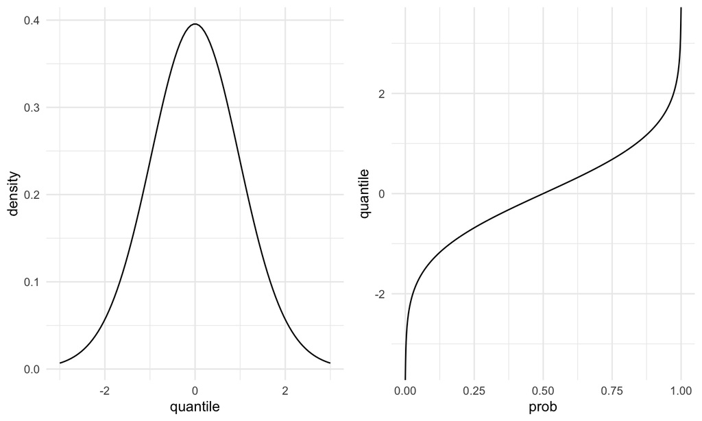

## Example with \(\beta_1\)

```r
low_95_ci <- beta1 + sigma_beta_1*qt(.025, df = nrow(peng) - 2)
high_95_ci <- beta1 + sigma_beta_1*qt(.975, df = nrow(peng) - 2)
```

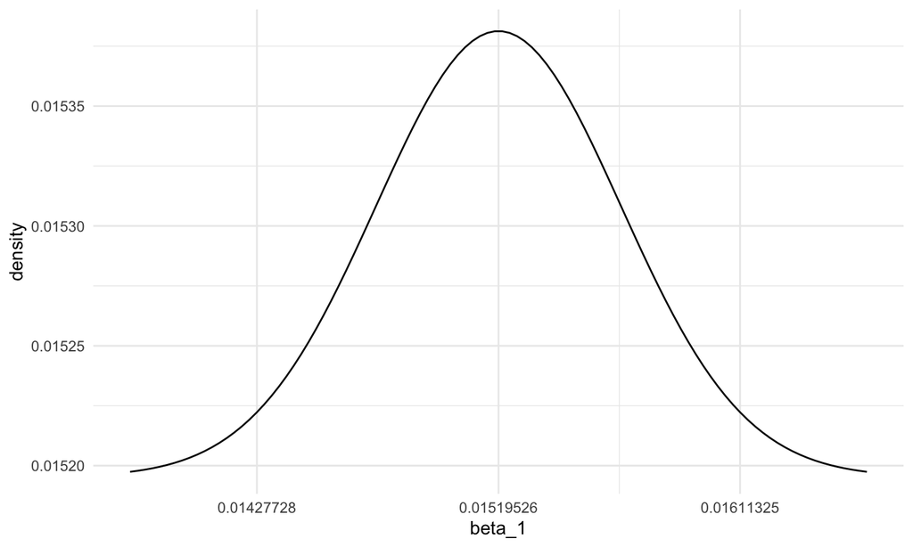

## Interpertaion of confidence interval

- It is not:
  - The true value of \(\beta_1\) has a 95% chance of falling between the low and high value
- More accurate:
  - If you repeat the experiment, you expect that 95% of the CIs contain the true value of \(beta_1\)

## Sampling Distribution of \(\hat\beta_0\)

\[ E\{\beta_0\} = \hat{\beta_0} \\ \sigma^2\{\beta_0\} = \hat\sigma^2 \left[\frac{1}{n} + \frac{\bar{X}^2}{\sum{(X_i - \bar{X})^2}} \right] \]

```r
sigma_beta_0 <- sqrt(sigma^2*(1/nrow(peng) + mean(peng$body_mass_g)^2/
                                sum((peng$body_mass_g - mean(peng$body_mass_g))^2)))
```

## Sampling Distribution Around \(\hat{Y}\)

\[ E\{\hat{Y}_h\} = \hat{\beta_0} + \hat\beta_1X_h \\ \sigma^2\{\hat{Y}_h\} = \hat\sigma^2 \left[\frac{1}{n} + \frac{(X_h - \bar{X})^2}{\sum{(X_i - \bar{X})^2}} \right] \]

- What happens when X_h = 0?
- What happens when we are far from \(\bar{X}\)?

## Distribution for \(\hat{Y}\)

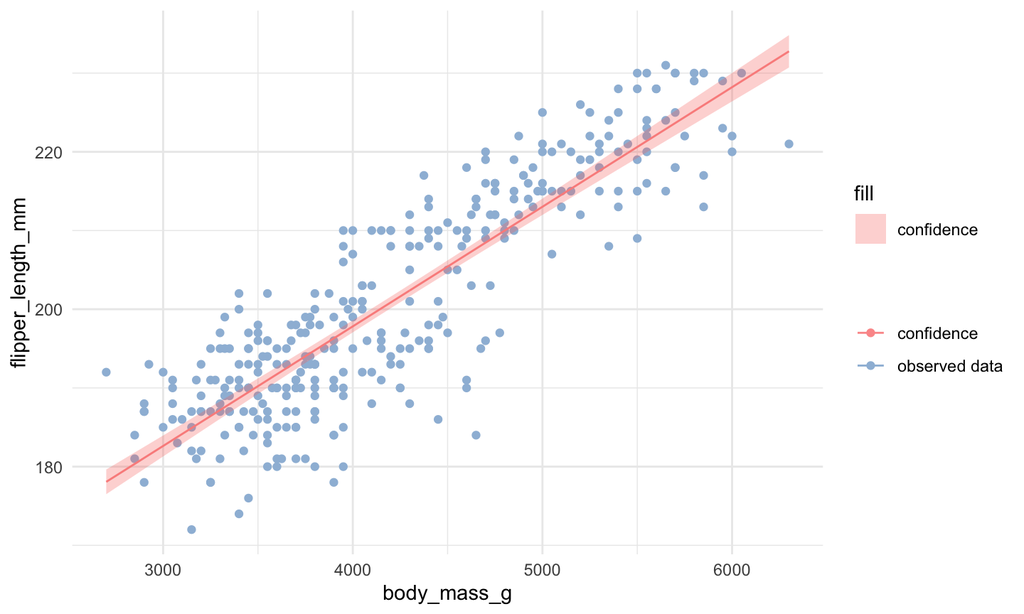

## Sampling Distribution around new observation (prediction)

\[ E\{\hat{Y}_{new}\} = \hat{\beta_0} + \hat\beta_1X_h \\ \sigma^2\{\hat{Y}_{new}\} = \hat\sigma^2 \left[1 + \frac{1}{n} + \frac{(X_h - \bar{X})^2}{\sum{(X_i - \bar{X})^2}} \right] \]

## Sampling Distribution around new observation (prediction)

- if you have \(m\) new observations at a given \(X_h\)

\[ \sigma^2\{\hat{Y}_{new_m}\} = \hat\sigma^2 \left[\frac{1}{m} + \frac{1}{n} + \frac{(X_h - \bar{X})^2}{\sum{(X_i - \bar{X})^2}} \right] \]

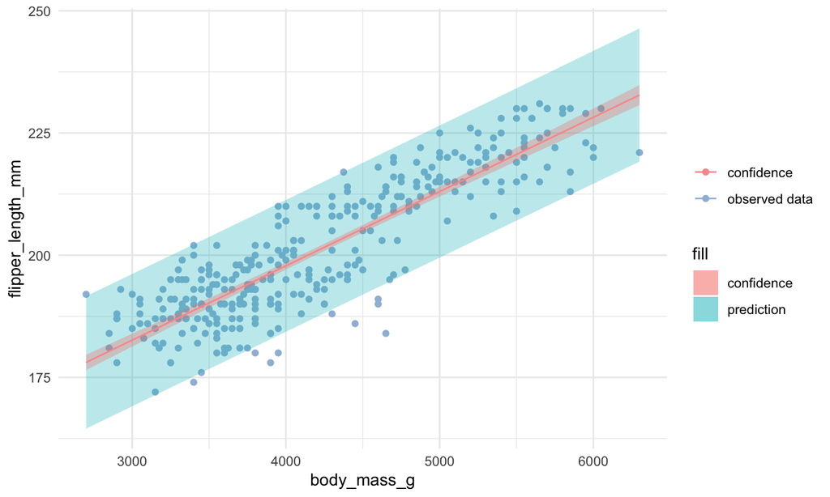

## Hypothesis Test

## Setup

- We often wish to determine the significance of a variable or multiple variables. We must create a null hypothesis and an alternative hypothesis to test

\[ H_0: \beta_1 = 0 \\ H_a: \beta_1 \neq 0 \] We set an alpha level which is the probability of rejecting the null hypothesis given that it’s true. Columns show what is true:

| Study Says | \(H_0\) | \(H_a\) |
| --- | --- | --- |
| No effect | Correct | Type II (\(\beta\)) |
| Effect | Type I (\(\alpha\)) | Correct |

## How to set \(\alpha\)?

- Often times alpha is set at .05
- However it should depend on the application used
- How bad is it if you say there is an effect when there isn’t one?

## What about \(\beta\)?

- This is related to your ability to detect an effect
- What are the two things that influence this (given a model)?

## P value

- The probability that you observe data at least as extreme as yours given the null hypothesis
- This is not the probability that your null hypothesis is true because you are assuming it already is

A low p value can happen:

- The null is true but your sample is unusual
- the null is false

## Calculating the p-value for the hypothesis above

\[ \frac{\hat\beta_1 - E\{\hat\beta_1\}}{\hat\sigma^2\{\hat\beta_1\}} \sim t(n-2) \]

if \(H_0\) is true then \(E\{\hat\beta_1\} = 0\) therefore:

\[ \frac{\hat\beta_1}{\hat\sigma^2\{\hat\beta_1\}} \sim t(n-2) \]

```r
pt(abs(beta1/sigma_beta_1^2), df = nrow(peng) - 2, lower.tail = FALSE)*2
```

```
## body_mass_g
##           0
```

## Create a fake variable for illustration

```r
fake_est
```

```
## fake_random
##   -0.889426
```

```r
fake_est_se
```

```
## [1] 0.7354721
```

```r
fake_est/fake_est_se
```

```
## fake_random
##   -1.209327
```

```r
pt(fake_est/fake_est_se, df = nrow(peng) - 2, lower.tail = TRUE) * 2
```

```
## fake_random
##   0.2274004
```

- This gives the same values as the F test for a single variable (see reading)

## Why double?

- We aren’t assuming a direction sowe have to check both sides of the t-distribution

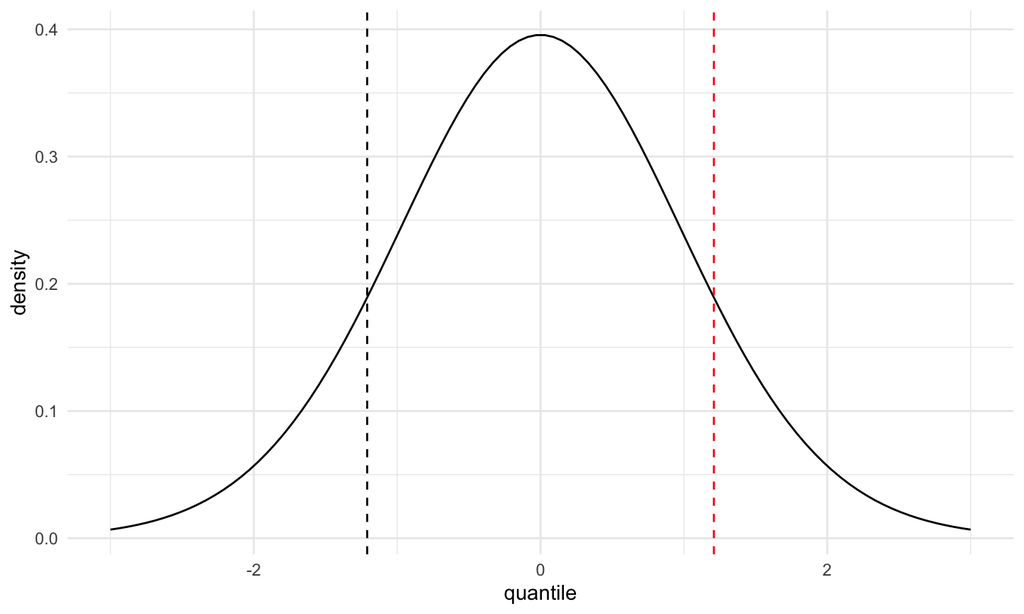

## Diagnostics

## R Squared

- The \(R^2\), also called the coefficient of determination or percentage of variance explained:

\[ R^2 = 1 - \frac{\sum(\hat{y}_i - y_i)^2}{\sum(\bar{y}_i - y_i)^2} = 1 - \frac{RSS}{TSS} \] - What kind of model definition means that \(\bar{y} =\hat{y}\)?

## \(R^2\) - what is it good for?

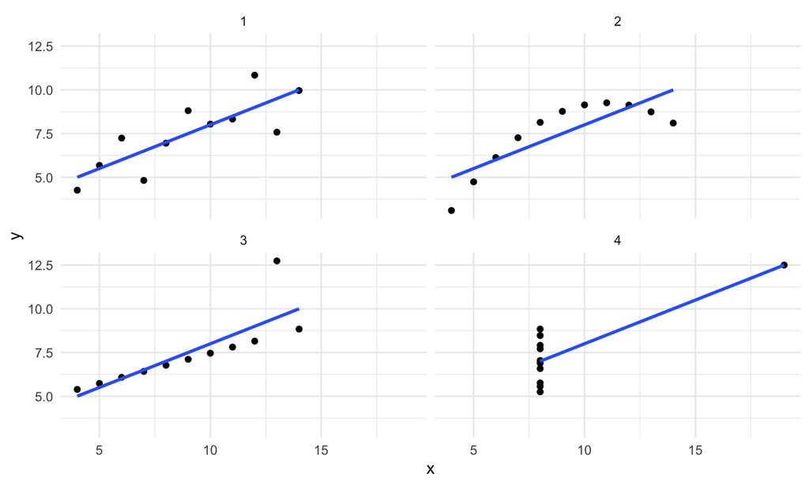

## \(R^2\) words of caution

- Always improves with more predictors (number of predictors: \(p\))

\[ R_a^2 = 1 - \frac{RSS/(n-p)}{TSS/(n-1)} \]

- Is not easily generalized to other types of models - the deviance is more general.
- For the linear model the deviance is the RSS

## Residuals

- In my opinion the best way to diagnose model issues
- Make sure nothing totally wrong is happening

## Residuals

### predictor variable (1)

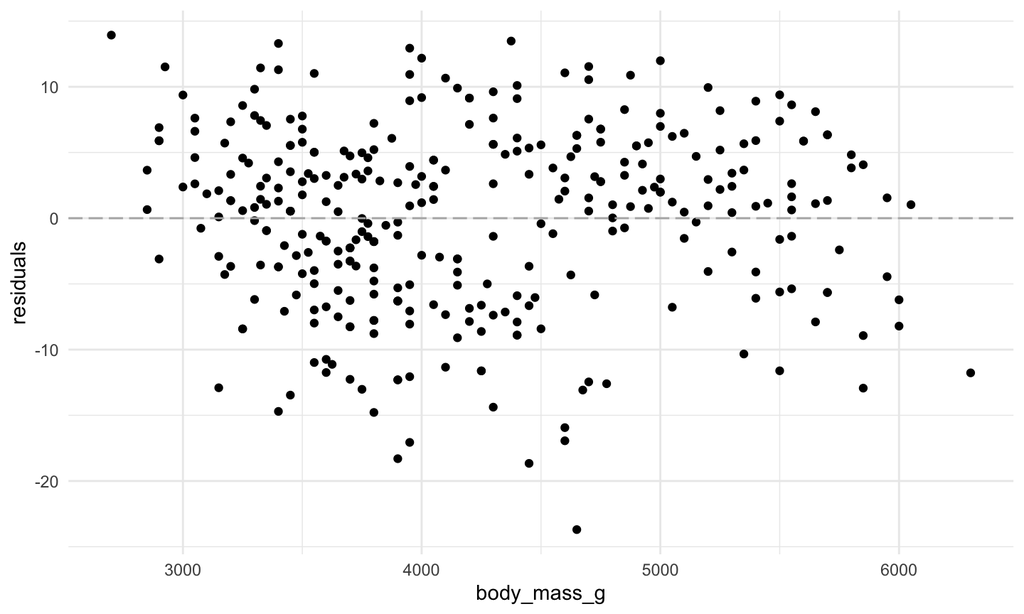

## Residuals

### predictor variable (2)

```r
bill_length_mod <- lm(bill_length_mm ~ body_mass_g, data = peng)
bill_length_residuals <- residuals(bill_length_mod)
```

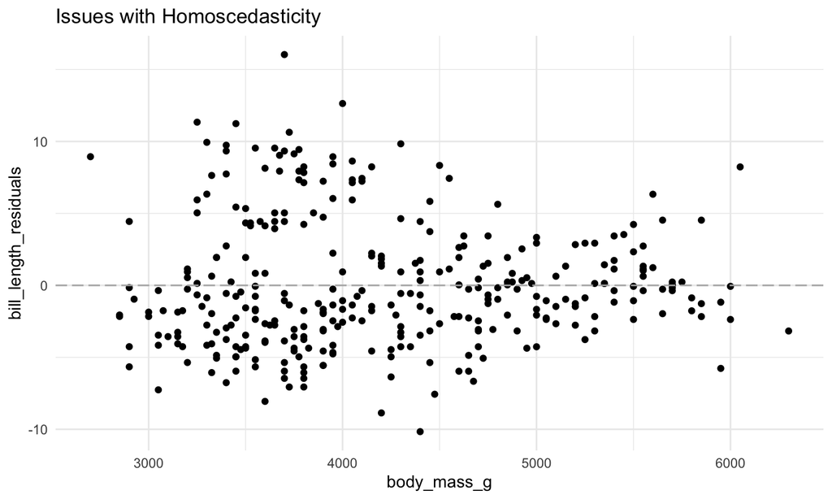

## Residuals| Fitted Values

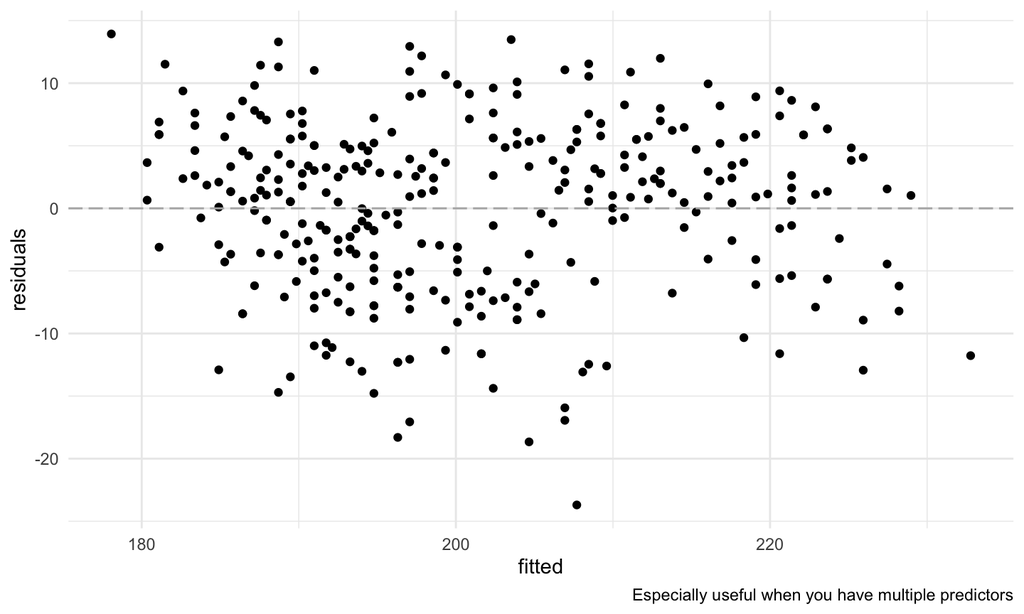

## Residuals

### Normal Q-Q Plot

- Standardized residuals

\[ var(\hat\epsilon) = \hat\sigma^2(1-h_{ii}) \] where \(h_ii\) is the leverage of a point which is defined as:

\[ Hy = X(X'X)^{-1}X'y = \hat y \]

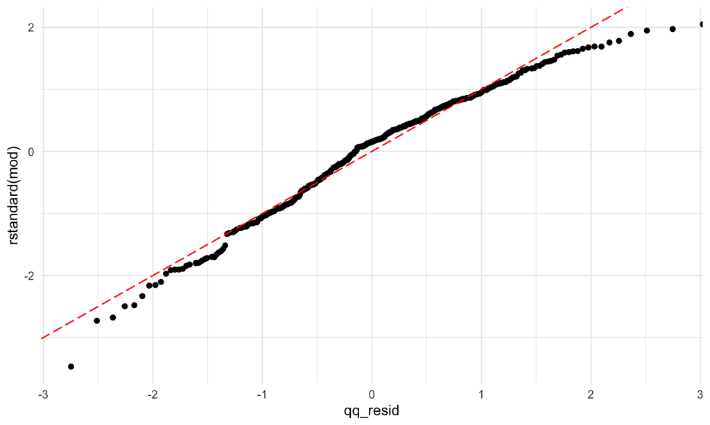

## Residuals

### Against other predictor

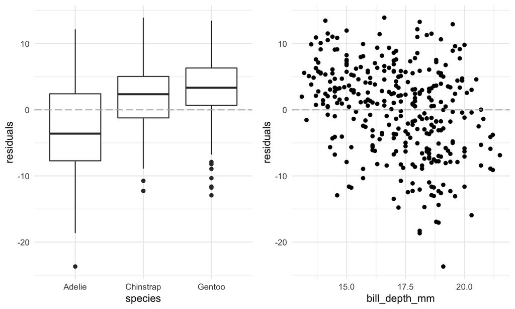

## Extending the ordinary model

## Let’s add predictors

\[ Y = \beta_0 + \beta_1X_1 + \beta_2X_2 + \cdots + \beta_{p-1}X_{p-1} +\beta_pX_p \]

## Add species as another variable

### original model

```r
model1 <- lm(flipper_length_mm ~ body_mass_g, data = peng)
summary(model1)
```

```
##
## Call:
## lm(formula = flipper_length_mm ~ body_mass_g, data = peng)
##
## Residuals:
##     Min      1Q  Median      3Q     Max
## -23.698  -4.983   1.056   5.101  13.933
##
## Coefficients:
##              Estimate Std. Error t value Pr(>|t|)
## (Intercept) 1.370e+02  1.999e+00   68.56   <2e-16 ***
## body_mass_g 1.520e-02  4.667e-04   32.56   <2e-16 ***
## ---
## Signif. codes:  0 '***' 0.001 '**' 0.01 '*' 0.05 '.' 0.1 ' ' 1
##
## Residual standard error: 6.847 on 331 degrees of freedom
## Multiple R-squared:  0.7621, Adjusted R-squared:  0.7614
## F-statistic:  1060 on 1 and 331 DF,  p-value: < 2.2e-16
```

## Add species as another variable

### adding species

```r
model2 <- lm(flipper_length_mm ~ body_mass_g + species, data = peng)
summary(model2)
```

```
##
## Call:
## lm(formula = flipper_length_mm ~ body_mass_g + species, data = peng)
##
## Residuals:
##      Min       1Q   Median       3Q      Max
## -14.5418  -3.1804   0.0983   3.3295  17.3954
##
## Coefficients:
##                   Estimate Std. Error t value Pr(>|t|)
## (Intercept)      1.585e+02  2.435e+00  65.119  < 2e-16 ***
## body_mass_g      8.515e-03  6.457e-04  13.186  < 2e-16 ***
## speciesChinstrap 5.492e+00  7.938e-01   6.918  2.4e-11 ***
## speciesGentoo    1.533e+01  1.117e+00  13.727  < 2e-16 ***
## ---
## Signif. codes:  0 '***' 0.001 '**' 0.01 '*' 0.05 '.' 0.1 ' ' 1
##
## Residual standard error: 5.405 on 329 degrees of freedom
## Multiple R-squared:  0.8526, Adjusted R-squared:  0.8513
## F-statistic: 634.4 on 3 and 329 DF,  p-value: < 2.2e-16
```

## Qualitative Variables

- Create dummy variables

| species | speciesChinstrap | speciesGentoo |
| --- | --- | --- |
| Adelie | 0 | 0 |
| Gentoo | 0 | 1 |
| Chinstrap | 1 | 0 |

## Add species as another variable

### adding species

```
##
## Call:
## lm(formula = flipper_length_mm ~ body_mass_g + species, data = peng)
##
## Residuals:
##      Min       1Q   Median       3Q      Max
## -14.5418  -3.1804   0.0983   3.3295  17.3954
##
## Coefficients:
##                   Estimate Std. Error t value Pr(>|t|)
## (Intercept)      1.585e+02  2.435e+00  65.119  < 2e-16 ***
## body_mass_g      8.515e-03  6.457e-04  13.186  < 2e-16 ***
## speciesChinstrap 5.492e+00  7.938e-01   6.918  2.4e-11 ***
## speciesGentoo    1.533e+01  1.117e+00  13.727  < 2e-16 ***
## ---
## Signif. codes:  0 '***' 0.001 '**' 0.01 '*' 0.05 '.' 0.1 ' ' 1
##
## Residual standard error: 5.405 on 329 degrees of freedom
## Multiple R-squared:  0.8526, Adjusted R-squared:  0.8513
## F-statistic: 634.4 on 3 and 329 DF,  p-value: < 2.2e-16
```

## Variable Selection

Look at AIC when fitting data using MLE

\[ AIC = -2l + 2p \] where \(l\) is the maximum log likelihood and p is the number of parameters

a smaller number is better

```r
AIC(model1)
```

```
## [1] 2230.228
```

```r
AIC(model2)
```

```
## [1] 2074.794
```

## Matrix Approach

## Matrix Approach

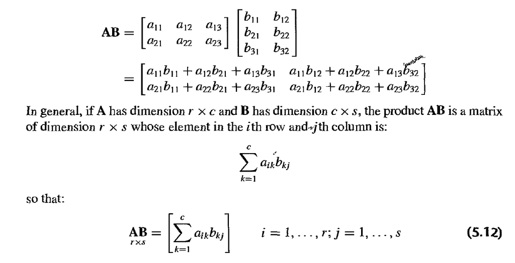

## Inverse of matrix

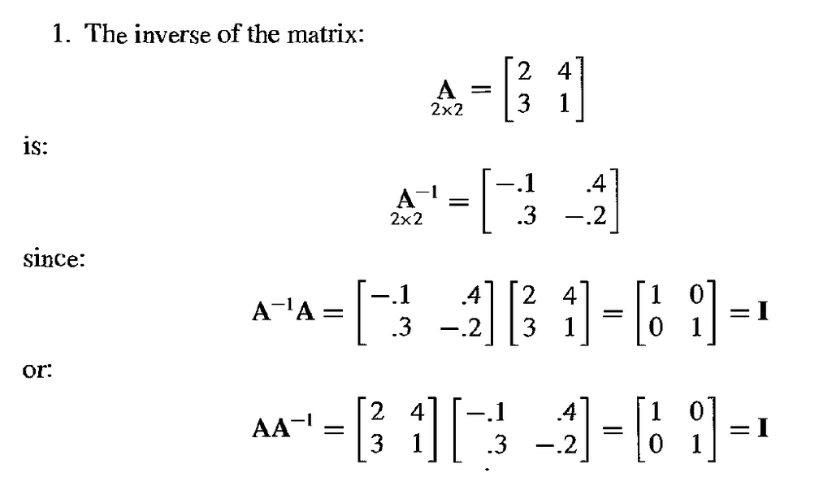

## Other Matrix Properties

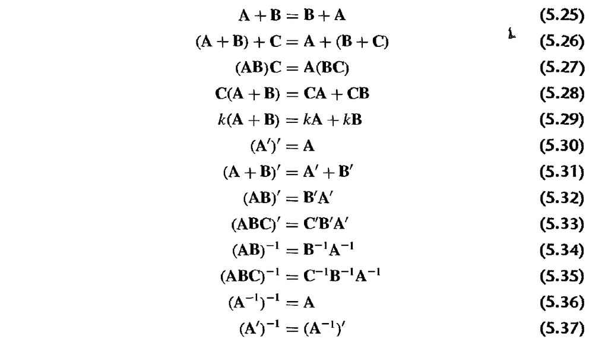

## Variance-Covariance Matrix

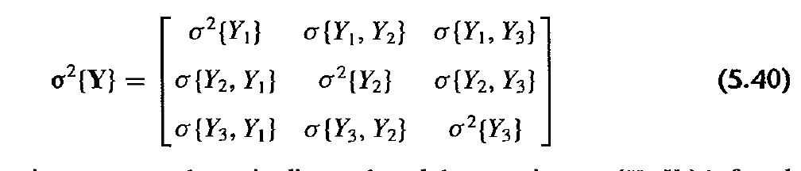

## Simple Model in Matrix Form

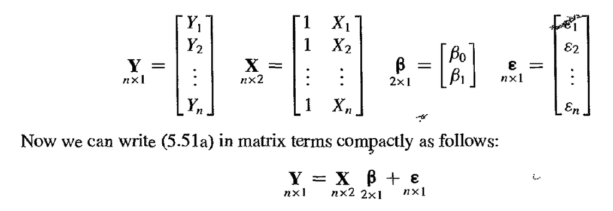